# Health and Economoic Consequences of Severe Weather Events

David Russo

Thursday, July 24, 2014

## DATA PROCESSING

We first set the working directory to that which has a “Data” folder containing the data file, and then read in the data in the following way.

```r
setwd("C:/Users/David/Classes/Coursera/JohnsHopkinsDataScienceSignatureTrack/Reproducible_Research/ProgAssign2")
data <- read.table("./Data/repdata-data-StormData (1).csv.bz2", header=T, sep = ",")
```

We looked at the size of the data frame to get a sense of what we’re working with.

```r
dim(data)
```

```
## [1] 902297     37
```

We looked at the number unique event types listed in the EVTYPE column

```r
length(unique(data$EVTYPE))
```

```
## [1] 985
```

That seemed to be an unreasonable number of weather event types, so we looked a little closer to see what they were, and saw a number of ways that cleaning the data would reduce the number of event types. But before beggining to clean the data, we created a copy of the dataframe in order to keep the original pure.

```r
cleandata <- data
```

Then we changed the event names to all lower case, so that case is not a factor.

```r
cleandata$EVTYPE <- tolower(cleandata$EVTYPE)
```

Then we were ready to clean. One thing we saw was that there were 76 event types that were “summary of (date)”.

```r
cleandata$EVTYPE[grepl("summary",cleandata$EVTYPE)]
```

```
##  [1] "summary jan 17"         "summary of march 14"
##  [3] "summary of march 23"    "summary of march 24"
##  [5] "summary of april 3rd"   "summary of april 12"
##  [7] "summary of april 13"    "summary of april 21"
##  [9] "summary august 11"      "summary of april 27"
## [11] "summary of may 9-10"    "summary of may 10"
## [13] "summary of may 13"      "summary of may 14"
## [15] "summary of may 22 am"   "summary of may 22 pm"
## [17] "summary of may 26 am"   "summary of may 26 pm"
## [19] "summary of may 31 am"   "summary of may 31 pm"
## [21] "summary of june 3"      "summary of june 4"
## [23] "summary june 5-6"       "summary june 6"
## [25] "summary of june 11"     "summary of june 12"
## [27] "summary of june 13"     "summary of june 15"
## [29] "summary of june 16"     "summary june 18-19"
```

[output cut: 23 more lines]

We decided to remove those rows by by subsetting cleandata to be the data where “summary” is NOT in the EVTYPE.

```r
cleandata <- subset(cleandata,!(grepl("summary",cleandata$EVTYPE)))
```

We also saw groupings of event types that had very SIMILAR names to each other, or that seemed to be getting at the same general event type. We decided it would be best to unify these different but similar events under a common event name.

```r
cleandata$EVTYPE[grepl("wint",cleandata$EVTYPE)] <- "winter weather"
cleandata$EVTYPE[grepl("sleet",cleandata$EVTYPE)] <- "winter weather"
cleandata$EVTYPE[grepl("snow",cleandata$EVTYPE)] <- "winter weather"
cleandata$EVTYPE[grepl("freezing",cleandata$EVTYPE)] <- "winter weather"
cleandata$EVTYPE[grepl("frost",cleandata$EVTYPE)] <- "winter weather"
cleandata$EVTYPE[grepl("ice",cleandata$EVTYPE)] <- "winter weather"
cleandata$EVTYPE[grepl("hail",cleandata$EVTYPE)] <- "winter weather"
cleandata$EVTYPE[grepl("bliz",cleandata$EVTYPE)] <- "winter weather"
cleandata$EVTYPE[grepl("aval",cleandata$EVTYPE)] <- "avalanche"
cleandata$EVTYPE[grepl("flood",cleandata$EVTYPE)] <- "flood"
cleandata$EVTYPE[grepl("seas",cleandata$EVTYPE)] <- "flood"
cleandata$EVTYPE[grepl("surf",cleandata$EVTYPE)] <- "flood"
cleandata$EVTYPE[grepl("swells",cleandata$EVTYPE)] <- "flood"
cleandata$EVTYPE[grepl("wave",cleandata$EVTYPE)] <- "flood"
cleandata$EVTYPE[grepl("water",cleandata$EVTYPE)] <- "flood"
cleandata$EVTYPE[grepl("rip",cleandata$EVTYPE)] <- "flood"
cleandata$EVTYPE[grepl("drought",cleandata$EVTYPE)] <- "drought"
cleandata$EVTYPE[grepl("wind",cleandata$EVTYPE)] <- "wind"
cleandata$EVTYPE[grepl("heat",cleandata$EVTYPE)] <- "heat"
cleandata$EVTYPE[grepl("hurr",cleandata$EVTYPE)] <- "hurricane"
cleandata$EVTYPE[grepl("thermia",cleandata$EVTYPE)] <- "hypothermia"
cleandata$EVTYPE[grepl("lightning",cleandata$EVTYPE)] <- "lightning"
cleandata$EVTYPE[grepl("thunder",cleandata$EVTYPE)] <- "thunder storm"
cleandata$EVTYPE[grepl("tornado",cleandata$EVTYPE)] <- "tornado"
cleandata$EVTYPE[grepl("fire",cleandata$EVTYPE)] <- "wild fire"
```

We then took another look at the number of, and names of, unique event types in this cleaned data set.

```r
length(unique(cleandata$EVTYPE))
```

```
## [1] 232
```

```r
unique(cleandata$EVTYPE)
```

```
##   [1] "tornado"                       "wind"
##   [3] "winter weather"                "record cold"
##   [5] "hurricane"                     "heavy rain"
##   [7] "lightning"                     "dense fog"
##   [9] "flood"                         "thunder storm"
##  [11] "funnel cloud"                  "heat"
##  [13] "lighting"                      "heavy rains"
##  [15] "funnel"                        "wall cloud"
##  [17] "cold"                          "wall cloud/funnel cloud"
##  [19] "extreme cold"                  "freeze"
##  [21] "high tides"                    "record high temperature"
##  [23] "record high"                   "record low"
##  [25] "low temperature record"        "avalanche"
##  [27] "marine mishap"                 "high temperature record"
##  [29] "record high temperatures"      "severe turbulence"
```

[output cut: 101 more lines]

This looked much better, so we began to look at our study questions:

Question 1: Across the United States, which types of events are most harmful with respect to population health?

We took a sum of the FATALITIES and INJURIES variables over each EVTYPE, then added together the injuries + fatalities to create a new column quantifying the total harmful effect on health.

```r
library(plyr)
sums <- ddply(cleandata, .(EVTYPE), summarize, Fatalities=sum(FATALITIES), Injuries=sum(INJURIES))
sums$sum <- sums$Fatalities + sums$Injuries
```

For further simplification we reduced the number of event types by removing any rows that have sum=0. We first changed all zeros in the sum column to be NA, then removed all rows with NA in sum column.

```r
sums$sum[sums$sum==0] <- NA
sums <- sums[complete.cases(sums),]
dim(sums)
```

```
## [1] 53  4
```

Lastly, to prepare for the results in the next section, we ordered the dataframe, descending, by the sum of harmful effect on health.

```r
ordered <- arrange(sums, desc(sum))
```

Question 2: Across the United States, which types of events have the greatest economic consequences?

The variables that quantify economic consequences in dollars are PROPDMG(property damage) and CROPDMG(crop damage). They each have an additional corresponding variable of PROPDMGEXP and CROPDMGEXP, which are multipliers, where H=Hundred, K=Thousand, M=Million, and B=Billion. So we created new fields, PROPCASH and CROPCASH, which will combine the DMG and DMGEXP fields to create an actual numeric value.

We subset the variables we need into a new data frame, just for ease of viewing.

```r
datasubset <- subset(cleandata,select=c(EVTYPE,PROPDMG,PROPDMGEXP,CROPDMG,CROPDMGEXP))
```

We created our new columns of actual numeric values with nested ifelse statements.

```r
datasubset$PROPCASH <- ifelse(datasubset$PROPDMGEXP=="H",datasubset$PROPDMG*100,
                  ifelse(datasubset$PROPDMGEXP=="K",datasubset$PROPDMG*1000,
                  ifelse(datasubset$PROPDMGEXP=="M",datasubset$PROPDMG*1000000,
                  ifelse(datasubset$PROPDMGEXP=="B",datasubset$PROPDMG*1000000000,
                  datasubset$PROPDMG))))

datasubset$CROPCASH <- ifelse(datasubset$CROPDMGEXP=="H",datasubset$CROPDMG*100,
                  ifelse(datasubset$CROPDMGEXP=="K",datasubset$CROPDMG*1000,
                  ifelse(datasubset$CROPDMGEXP=="M",datasubset$CROPDMG*1000000,
                  ifelse(datasubset$CROPDMGEXP=="B",datasubset$CROPDMG*1000000000,
                  datasubset$CROPDMG))))
```

We summed PROPCASH and CROPCASH over each EVTYPE, and added together the PropCash + CropCash, creating a new column quantifying the total economic impact.

```r
library(plyr)
sums2 <- ddply(datasubset, .(EVTYPE), summarize, PropCash=sum(PROPCASH), CropCash=sum(CROPCASH))
sums2$sum <- sums2$PropCash + sums2$CropCash
```

For further simplification we reduced the number of event types by removing any rows that have sum=0. We first changed all zeros in the sum column to be NA, then removed all rows with NA in sum column.

```r
sums2$sum[sums2$sum==0] <- NA
sums2 <- sums2[complete.cases(sums2),]
dim(sums2)
```

```
## [1] 90  4
```

Lastly, to prepare for the results in the next section, we order the dataframe, descending, by the sum economic impact.

```r
ordered2 <- arrange(sums2, desc(sum))
```

## RESULTS

Question 1: Across the United States, the top 10 severe weather events that were most harmful with respect to population health are the following, with their associated number of injuries and fatalities, and a plot of their sum total effect on health.

```r
head(ordered,10)
```

```
##            EVTYPE Fatalities Injuries   sum
## 1         tornado       5633    91364 96997
## 2            wind       1405    11324 12729
## 3           flood       2524     9897 12421
## 4            heat       2955     8830 11785
## 5  winter weather        704     7601  8305
## 6       lightning        817     5232  6049
## 7       wild fire         90     1608  1698
## 8       hurricane        133     1326  1459
## 9             fog         62      734   796
## 10     dust storm         22      440   462
```

[output not shown]

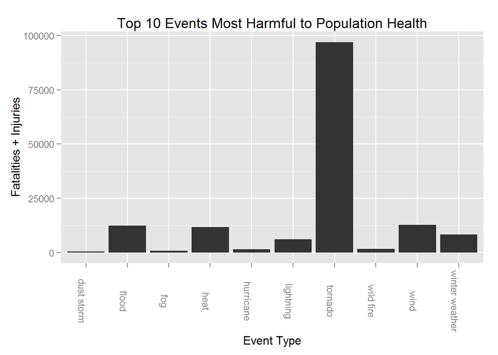

```r
plotdata <- head(ordered,10)
library(ggplot2)
q <- qplot(EVTYPE,sum,data=plotdata,geom="bar",
           xlab="Event Type",
           ylab="Fatalities + Injuries",
           main="Top 10 Events Most Harmful to Population Health")
q + theme(axis.text.x=element_text(angle=-90))
```

Question 2: Across the United States, the top 10 severe weather events that had the greatest economic consequences are the following, with their associated property and crop damage, and a plot of their sum total dollar cost.

```r
head(ordered2,10)
```

```
##              EVTYPE  PropCash  CropCash       sum
## 1             flood 1.677e+11 1.242e+10 1.801e+11
## 2         hurricane 8.464e+10 5.495e+09 9.013e+10
## 3           tornado 5.693e+10 4.150e+08 5.735e+10
## 4       storm surge 4.332e+10 5.000e+03 4.332e+10
## 5    winter weather 3.007e+10 9.637e+09 3.971e+10
## 6              wind 1.602e+10 1.974e+09 1.799e+10
## 7           drought 1.046e+09 1.397e+10 1.502e+10
## 8         wild fire 8.497e+09 4.033e+08 8.900e+09
## 9    tropical storm 7.704e+09 6.783e+08 8.382e+09
## 10 storm surge/tide 4.641e+09 8.500e+05 4.642e+09
```

[output not shown]

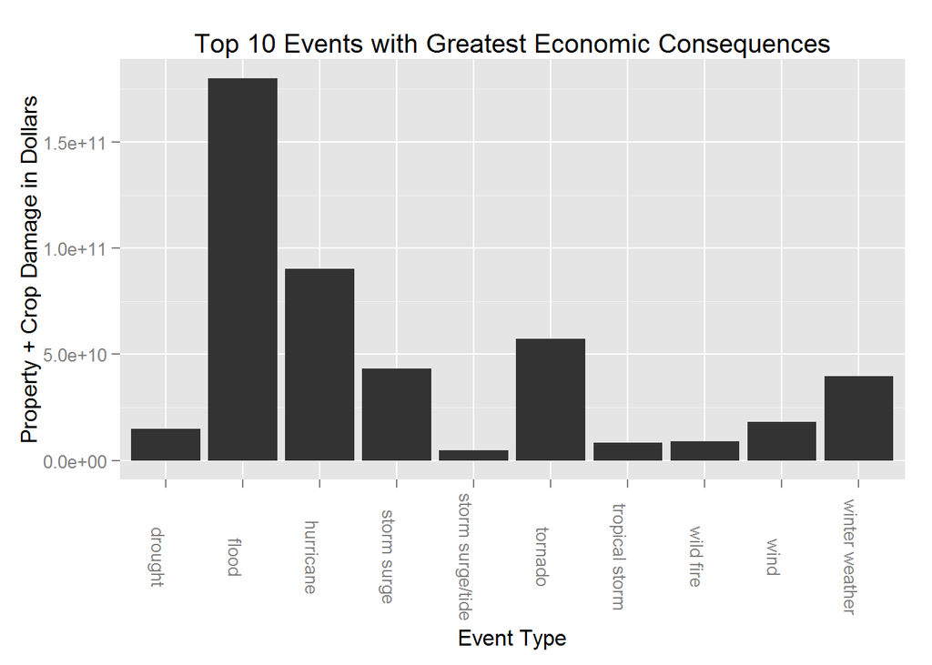

```r
plotdata2 <- head(ordered2,10)
library(ggplot2)
q <- qplot(EVTYPE,sum,data=plotdata2,geom="bar",
           xlab="Event Type",
           ylab="Property + Crop Damage in Dollars",
           main="Top 10 Events with Greatest Economic Consequences")
q + theme(axis.text.x=element_text(angle=-90))
```